# Econometrics 2

Willi Mutschler

# Heteroscedasticity

Let’s consider the rent example from the textbook

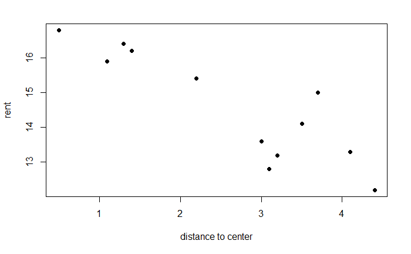

```r
# data
x <- c(0.5,1.4,1.1,2.2,1.3,3.2,3.1,4.4,3.7,3,3.5,4.1)
y <- c(16.8,16.2,15.9,15.4,16.4,13.2,12.8,12.2,15,13.6,14.1,13.3)
# plot
plot(x,y,xlab="distance to center",ylab="rent",pch=19)
```

## Goldfeld-Quandt-Test

$$H_0: \sigma^2_{II} \leq \sigma^2_{I} \text{ vs. } H_1: \sigma^2_{II} > \sigma^2_{I}$$

1. Estimation for group inner-city (Observations 1…5)

```r
regrC <- lm(y[1:5]~x[1:5])
SuuC <- sum(residuals(regrC)^2)
print(SuuC)
```

```
[1] 0.2456
```

2. Estimation for group suburban (Observations 6…12)

```r
regrS <- lm(y[6:12]~x[6:12])
SuuS <- sum(residuals(regrS)^2)
print(SuuS)
```

```
[1] 4.665904
```

3. Compute test statistic and critical value

```r
print(paste("Test statistic F =",(SuuS/5)/(SuuC/3)))
```

```
[1] "Test statistic F = 11.3987893408634"
```

```r
print(paste("5% critical value =",qf(0.95,5,3)))
```

```
[1] "5% critical value = 9.01345516752258"
```

Hence, we reject the null hypothesis. It seems like there is heteroskedasticity in the error term.

## White-Test

As we only have one exogenous variable (and the constant), the auxiliary model is
$$\hat{u}_t^2 = \gamma_0 + \gamma_1 x_{1t} + \gamma_2 x_{1t}^2 + v_t$$
We want to test the joint hypothesis that
$$H_0: \gamma_1=\gamma_2=0$$

```r
regr <- lm(y~x)
uhatsquared <- residuals(regr)^2
aux <- lm(uhatsquared~x+I(x^2))
TT <- length(uhatsquared)
summary_aux <- summary(aux)
TR2 <- summary_aux$r.squared*TT
print(paste("Test statistic T x R2 =",TR2))
```

```
[1] "Test statistic T x R2 = 2.36282698473085"
```

```r
print(paste("5% critical value =",qchisq(0.95,2)))
```

```
[1] "5% critical value = 5.99146454710798"
```

```r
print(paste("p-value of test statistic =",pchisq(TR2,2)))
```

[output not shown]

```r
print(summary_aux)
```

```
Call:
lm(formula = uhatsquared ~ x + I(x^2))

Residuals:
     Min       1Q   Median       3Q      Max
-0.57461 -0.44158 -0.19293  0.05284  1.75298

Coefficients:
            Estimate Std. Error t value Pr(>|t|)
(Intercept)  -0.7002     0.9421  -0.743    0.476
x             0.9002     0.8869   1.015    0.337
I(x^2)       -0.1381     0.1773  -0.779    0.456

Residual standard error: 0.7534 on 9 degrees of freedom
Multiple R-squared:  0.1969,    Adjusted R-squared:  0.01844
F-statistic: 1.103 on 2 and 9 DF,  p-value: 0.3728
```

Hence we cannot reject the null hypothesis. One can also look at the p-value of the F-statistic given in the summary. Note that the reliability of the White Test is not good in small samples.

# White’s Heteroskedasticity-Consistent (HC) Standard Errors

```r
X <- cbind(1,x) # make regressor matrix
betahat <- solve(t(X)%*%X)%*%t(X)%*%y #(X'X)^{-1}X'y, betahat is unbiased
uhat <- y-X%*%betahat
What <- diag(as.vector(uhat^2))
Covbetahat <- solve(t(X)%*%X)%*%t(X)%*%What%*%X%*%solve(t(X)%*%X)
print(paste("HC standard error for alpha =",sqrt(diag(Covbetahat)[1])))
```

```
[1] "HC standard error for alpha = 0.229904056922805"
```

```r
print(paste("(Wrong) LS standard error for alpha =",summary(lm(y~x))$coefficients[1,2]))
```

```
[1] "(Wrong) LS standard error for alpha = 0.527136990533692"
```

```r
print(paste("HC standard error for beta =",sqrt(diag(Covbetahat)[2])))
```

```
[1] "HC standard error for beta = 0.125608109232192"
```

```r
print(paste("(Wrong) LS standard error for beta =",summary(lm(y~x))$coefficients[2,2]))
```

```
[1] "(Wrong) LS standard error for beta = 0.18178038243164"
```

The (wrong) standard errors of the normal least squares estimators are larger than the HC standard errors.

# Autocorrelation

Let’s consider the waterfilter example from the textbook

```r
price <- c(24.2,25.5,26.8,26.4,25.2,24.4,26.2,26.1,27.4,28.4,29.8,31.3,32.2,32.4,33.2,34,33.7,32.8,31.3,30.9,30,28.3,27.5,26.8)
quant <- c(1990,1630,1570,1960,2150,2450,2210,2400,2200,1270,1250,1500,1700,1450,1480,1450,1000,1080,1270,1520,1820,1660,1500,1810)
n <- length(price)
regr <- lm(quant~price)
uhat <- residuals(regr)
plot(price,quant,xlab="Price",ylab="Demand (quantity)",pch=19)
abline(regr)
```

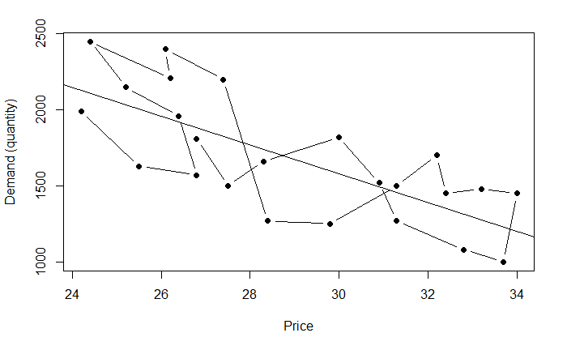

```r
lines(price,quant,type="b")
```

## Time series of residuals

Let’s look at the time series of residuals

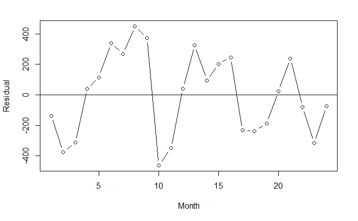

```r
plot(1:n,uhat,t="b",xlab="Month",ylab="Residual")
abline(h=0)
```

## Scatterplot of pairwise residuals

Let’s look at the scatterplot of pairwise residuals

```r
plot(uhat[-n],uhat[-1],xlab="lagged residual",ylab="residual",pch=19)
abline(h=0)
```

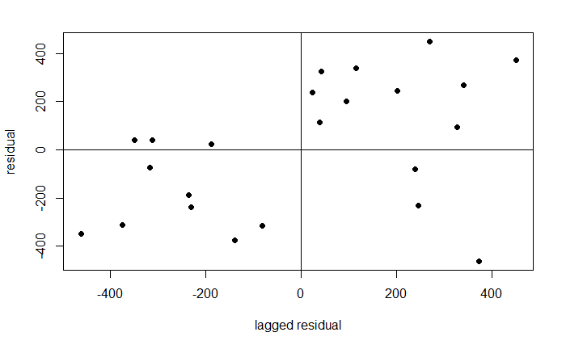

```r
abline(v=0)
```

## OLS estimation of AR(1) for residuals

OLS estimation of first-order autocorrelation in residuals

```r
print(summary(lm(uhat[-1]~uhat[-n])))
```

```
Call:
lm(formula = uhat[-1] ~ uhat[-n])

Residuals:
    Min      1Q  Median      3Q     Max
-633.13 -149.24   93.84  171.10  325.77

Coefficients:
            Estimate Std. Error t value Pr(>|t|)
(Intercept)   4.6056    52.3456   0.088   0.9307
uhat[-n]      0.4458     0.1943   2.295   0.0321 *
---
Signif. codes:  0 ‘***’ 0.001 ‘**’ 0.01 ‘*’ 0.05 ‘.’ 0.1 ‘ ’ 1

Residual standard error: 251 on 21 degrees of freedom
Multiple R-squared:  0.2005,    Adjusted R-squared:  0.1624
F-statistic: 5.267 on 1 and 21 DF,  p-value: 0.03214
```

## Hildreth-Lu

Note that the transformation matrix $P$ has the following form
$$P =
\frac{1}{\sqrt{1-\rho^2}}
\begin{bmatrix}
\sqrt{1-\rho^2} & 0 & 0 & ... & 0 & 0\\
-\rho & 1 & 0 & ... & 0 & 0\\
0 & -\rho & 1 & ... & 0 & 0\\
\vdots & \vdots & \vdots & \ddots & \vdots & \vdots\\
0 & 0 & 0 & ... & 1 & 0\\
0 & 0 & 0 & ... & -\rho & 1
\end{bmatrix}$$

```r
X <- cbind(1,price) # make regressor matrix
y <- quant
ngridpoints <- 199
Z <- matrix(NA,ngridpoints,ncol(X)) # initialize output matrix
rho0 <- seq(-0.99,0.99,length=199)
for(i in 1:199) {
  # create transformation matrix P
  P <- diag(n)
  P[1,1] <- sqrt(1-rho0[i]^2)
  for(j in 2:n) P[j,(j-1)] <- -rho0[i]
  P <- P/sqrt(1-rho0[i]^2)
  # Transform variables
  ystar <- P%*%y
  Xstar <- P%*%X
  # OLS on transformed variables
  regr <- lm(ystar~Xstar-1)
  uhatstar <- residuals(regr)
  Z[i,] <- c(rho0[i],sum(uhatstar^2)*(1-rho0[i]^2))
  }
rhostar <- Z[which.min(Z[,2]),1]
print(paste("The value of rho with minimum sum of squared residuals is ",rhostar))
```

```
[1] "The value of rho with minimum sum of squared residuals is  0.45"
```

[output not shown]